# Using dtw and gmm to classify song syllables

Exisiting tools for syllable classification rely on manual extraction of spectral and temporal features of each syllable. Here, I will test whether the distance metric from the dynamic time warp (which uses the entire spectrogram of each syllable) can be used for extracting features to be clustered with gaussian mixture models.

```matlab
addpath('~/code/evsonganaly/')
addpath('~/code/from_evren/')

%get sample song data from a bird's song
pathnm = '/opt/data/deaf_and_naspm/rd36gr25/saline_2_11_2018/';
batchlist = 'batch.keep';

%iterate through first 20 song files in directory and extract onsets, offsets, labels, and raw amplitude
%waveform for each song
ff = load_batchf([pathnm,batchlist]);
ons = []; offs = []; lbls = []; filtsong = [];
tm = 0;
for i = 1:20
    load([pathnm,ff(i).name,'.not.mat']);
    ons = [ons;onsets+tm];
    offs = [offs;offsets+tm];
    lbls = [lbls labels];
    [dat fs] = evsoundin(pathnm,ff(i).name,'obs0');
    filtsong = [filtsong; bandpass(dat,fs,300,10000,'hanningffir')];
    tm = tm+(length(dat)*1000)/fs;
end
```

```matlab
%spectrogram parameters
fs = 32000;%sampling rate for audio files
buff = 0.016*fs;%16 ms buffer at onsets and offsets
NFFT = 512;
overlap = NFFT-32;%1 ms
t=-NFFT/2+1:NFFT/2;
sigma=(1/1000)*fs;
w=exp(-(t/sigma).^2);%gaussian smoothing window

%set of syllables that song was manuall labelled
sylls = unique(lbls);
sylls = sylls(isletter(sylls))
```

```
sylls =

abcdefsw
```

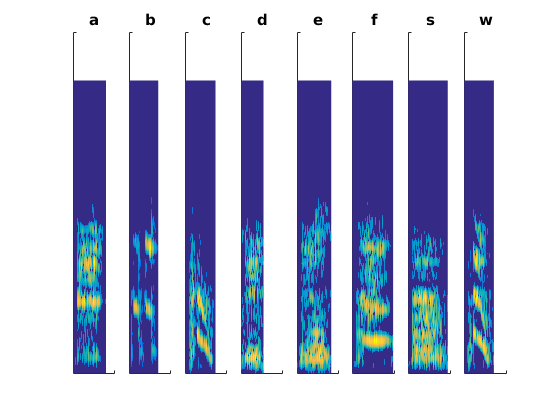

```matlab
%extract spectrograms of 10 renditions of each song syllable and visualize an example spectrogram for each syllable
templates = {};
figure;hold on;
for i = 1:length(sylls)
    ind = strfind(lbls,sylls(i));
    ix = ind(randsample(length(ind),10));
    for m = 1:length(ix)
        dat = filtsong(floor(ons(ix(m))*fs/1000)-buff:ceil(offs(ix(m))*fs/1000)+buff);
        sp = spectrogram(dat,w,overlap,NFFT,fs);
        sp = abs(sp);
        if m == 1
            subplot(1,length(sylls),i);hold on;
            sp2 = sp;
            ind = find(sp2<=mean(mean(sp2)));
            sp2(ind) = mean(mean(sp2))/2;
            imagesc(log(sp2));axis('xy');title(num2str(sylls(i)));set(gca,'XTickLabel',[],'YTickLabel',[])
        end
        sp = sp./sum(sp,2);%normalize the spectrogram at each time slice
        templates = [templates; sp];
    end
end
```

```matlab
%calculate distrance metric from dynamic time warp to each of the template spectrograms
%for every syllable instance
dist = NaN(length(lbls),length(templates));
for i = 1:length(templates)
    for ii = 1:length(lbls)
        dat = filtsong(floor(ons(ii)*fs/1000)-buff:ceil(offs(ii)*fs/1000)+buff);
        sp = spectrogram(dat,w,overlap,NFFT,fs);
        sp = abs(sp);
        sp = sp./sum(sp,2);%normalize the spectrogram at each time slice
        dist(ii,i) = dtw(templates{i},sp);
    end
end
```

```matlab
%feature matrix is mxn where m is observation and n is number of features = 80
disp([num2str(size(dist,1)),' observations each with ',num2str(size(dist,2)),' features']);
dist2 = dist;

%pca to reduce dimensionality of feature vectors
[c,s,~,~,explained] = pca(dist2);
ind_comp = find(cumsum(explained)<99);
dist2 = dist2*c(:,ind_comp);%project matrix on principal component space
disp([num2str(length(ind_comp)),' principal components']);
```

```
1736 observations each with 80 features
14 principal components
```

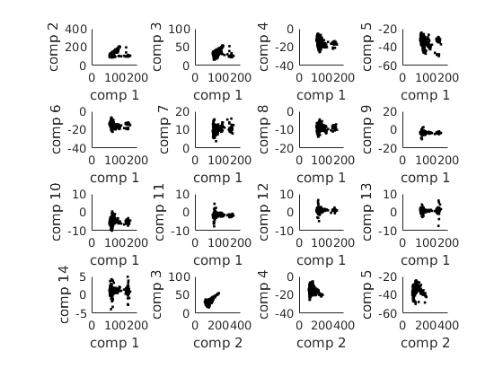

```matlab
%view example of syllable clusters in pca space
cmbs = combnk([1:length(ind_comp)],2);%all combinations of components
figure;hold on;
for i = 1:16;
    subplot(4,4,i);hold on;
    plot(dist2(:,cmbs(i,1)),dist2(:,cmbs(i,2)),'k.');
    xlabel(['comp ',num2str(cmbs(i,1))]);
    ylabel(['comp ',num2str(cmbs(i,2))]);
end
```

```
18 components
```

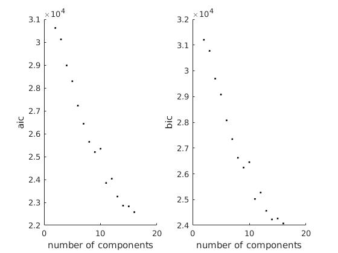

```matlab
%train gmm on a range of models with different components and compare BIC/AIC to identify in an unsupervised
%fashion the ideal model/number of components

%divide training set into 3 subsets
k = 3;%number of sets
nrow = size(dist2,1);
n = floor(nrow/k);%three sets
lens = floor(nrow/n);
subset = cell(3,1);
for i = 1:k
    subset{i} = dist2((i-1)*n+1:i*n,:);
end

%train on the k data subsets
models = 2:16;%range of component numbers to test
options = statset('MaxIter',10000);
aic=[];bic=[];
for m = 1:length(models)
    bics = [];aics = [];
    for y = 1:k
        trainset = cell2mat(subset(y));
        gmm = fitgmdist(trainset,models(m),'Options',options,'Replicates',5,'SharedCovariance',true,...
        'CovarianceType','full','RegularizationValue',0.01);
        bics = [bics;gmm.BIC];
        aics = [aics; gmm.AIC];
    end
    aic=[aic;mean(aics)];
    bic=[bic;mean(bics)];
end

%plot AIC/BIC
figure;subplot(1,2,1);hold on;plot(models,aic,'k.');ylabel('aic');xlabel('number of components');
subplot(1,2,2);hold on;plot(models,bic,'k.');ylabel('bic');xlabel('number of components');
[~,ind] = min(bic);
numcomponents = models(ind)+2;
disp([num2str(numcomponents),' components'])
```

```matlab
%train up gmm on chosen number of components
options = statset('MaxIter',100000);
gmm = fitgmdist(trainset,numcomponents,'Options',options,'Replicates',10,'SharedCovariance',true,...
'CovarianceType','full','RegularizationValue',0.01);
idx = cluster(gmm,dist2);%assign cluster number for each observation
```

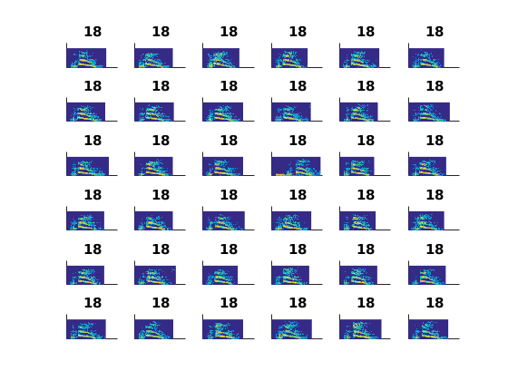

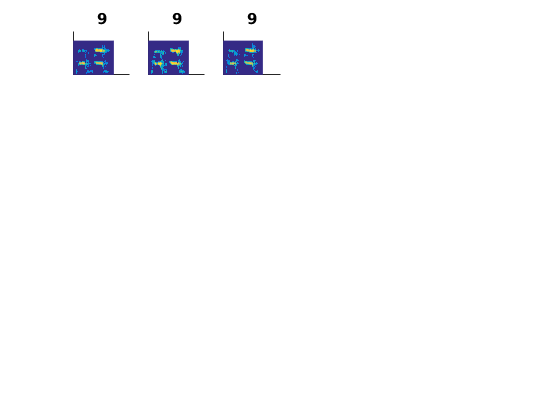

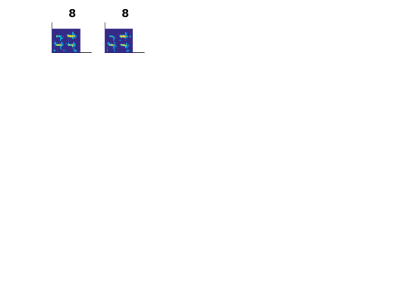

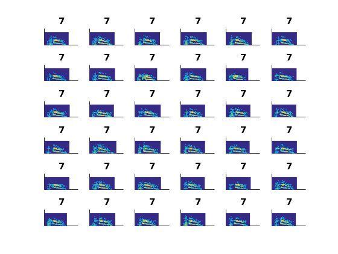

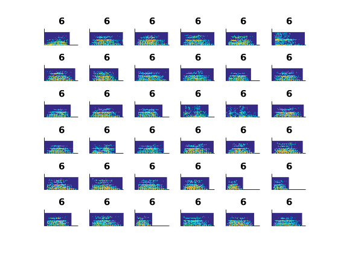

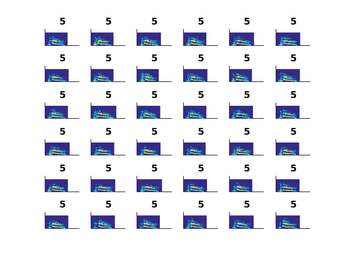

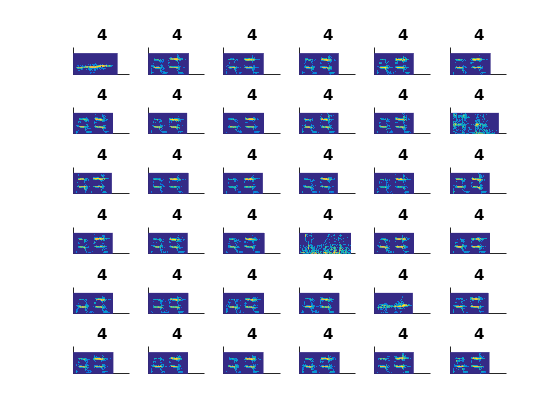

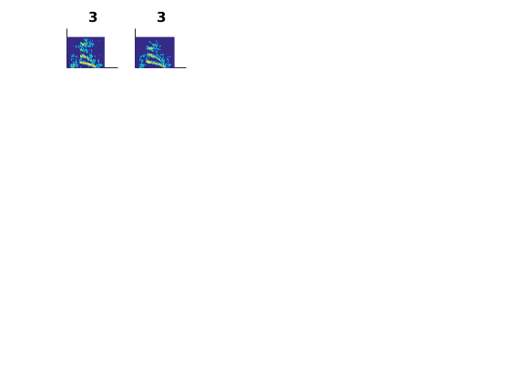

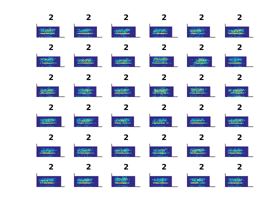

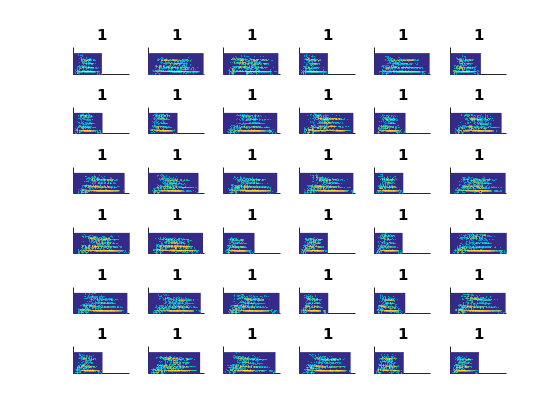

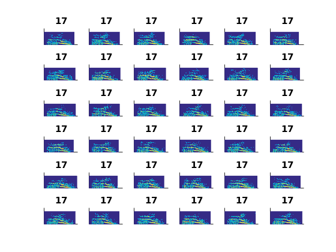

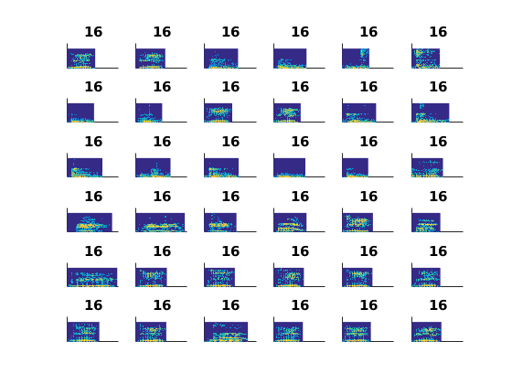

[6 more figures not shown]

```matlab
%visualize some of the spectrograms of the syllables within each cluster
for i = 1:numcomponents
    if ~isempty((find(idx==i)))
        figure;hold on;
        onset=ons(find(idx==i));
        offset = offs(find(idx==i));
        if length(find(idx==i))>36
            numspecs = 36;
        else
            numspecs = length(find(idx==i));
        end
        for ix = 1:numspecs
            subplot(6,6,ix);hold on;
            dat = filtsong(floor(onset(ix)*fs/1000)-buff:ceil(offset(ix)*fs/1000)+buff);
            [sp f] = spectrogram(dat,w,overlap,NFFT,fs);
            ind = find(f>=300 & f<=10000);%restrict spectrogram to within bandpass frequencies
            sp = abs(sp(ind,:));
            ind = find(abs(sp)<=mean(mean(abs(sp))));
            sp(ind)=mean(mean(abs(sp)))/2;
            imagesc(log(sp));axis('xy');title(num2str(i));set(gca,'XTickLabel',[],'YTickLabel',[])
        end
    end
end
```

Looks like the spectral content of the syllables within each cluster is largely uniform, except for some, like cluster 15 and 16. It also looks like that many clusters can be combined into one, or in other words, the gmm overfitted the number of models. Let's examine the manual labels in each cluster.

```matlab
for i = 1:numcomponents
    disp(['labels in cluster ',num2str(i),':',lbls(find(idx==i))])
end
```

[output not shown]

Based on comparison with manual labels: syllable a = cluster 2 syllable b = cluster 4,8,9 syllable c= cluster 5,7,11,12 syllable d = cluster 16 syllable e = cluster 13 syllable f = cluster 1 syllable s = cluster 6 syllable w = cluster 3,10,14,17,18 noise = cluster 15

```matlab
%store mapping of syllable label and cluster number in structure
lbl_to_cluster = struct('a',2,'b',[4,8,9],'c',[5,7,11,12],'d',16,'e',13,'f',1,'s',6,'w',[3,10,14,17,18]);
```

```matlab
%validate trained gmm on new set of syllables and compare with manual labels to get % correct

%extract syllables from another set of 20 songs that were not trained by gmm
ons2 = []; offs2 = []; lbls2 = []; filtsong2 = [];
tm2 = 0;
for i = 31:50
    load([pathnm,ff(i).name,'.not.mat']);
    ons2 = [ons2; onsets+tm2];
    offs2 = [offs2; offsets+tm2];
    lbls2 = [lbls2 labels];
    [dat fs] = evsoundin(pathnm,ff(i).name,'obs0');
    filtsong2 = [filtsong2; bandpass(dat,fs,300,10000,'hanningffir')];
    tm2= tm2+(length(dat)*1000)/fs;
end

%compute the distance metric to the 80 template syllables selected previously
dist_val = NaN(length(lbls2),length(templates));
for i = 1:length(templates)
    for ii = 1:length(lbls2)
        dat = filtsong2(floor(ons2(ii)*fs/1000)-buff:ceil(offs2(ii)*fs/1000)+buff);
        sp = spectrogram(dat,w,overlap,NFFT,fs);
        sp = abs(sp);
        sp = sp./sum(sp,2);
        dist_val(ii,i) = dtw(templates{i},sp);
    end
end
```

```matlab
disp([num2str(size(dist_val,1)),' observations in validation set'])
```

```
2215 observations in validation set
```

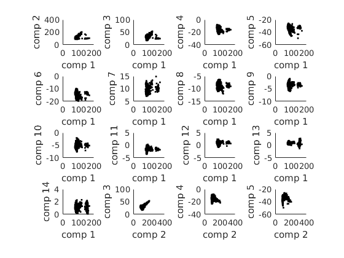

```matlab
%project distance matrix on pca space defined previously
dist2_val = dist_val;
dist2_val = dist2_val*c(:,ind_comp);

%view example of syllable clusters in pca space
figure;hold on;
for i = 1:16;
    subplot(4,4,i);hold on;
    plot(dist2_val(:,cmbs(i,1)),dist2_val(:,cmbs(i,2)),'k.');
    xlabel(['comp ',num2str(cmbs(i,1))]);
    ylabel(['comp ',num2str(cmbs(i,2))]);
end
```